# EDA Clustering (Eviden)

```python
import pandas as pd
import re, numpy as np
import matplotlib.pyplot as plt
from wordcloud import WordCloud
from nltk.corpus import stopwords
import nltk
import re
from collections import Counter
from langdetect import detect
from sklearn.feature_extraction.text import CountVectorizer
from sklearn.feature_extraction.text import TfidfVectorizer
from sklearn.cluster import KMeans
from sklearn.feature_extraction.text import ENGLISH_STOP_WORDS
from sklearn.decomposition import TruncatedSVD
from sklearn.metrics import silhouette_score
from sklearn.metrics.pairwise import cosine_similarity
from sklearn.feature_selection import chi2
```

```python
data = pd.read_csv("/Users/kaile/Downloads/Client Data EXTRACTED - Sheet1.csv")
```

```python
data.head()
```

|  | Company | Industry | Statement | Type |
| --- | --- | --- | --- | --- |
| 0 | advanced micro device | Technology | Build great products that accelerate next-gene... | mission |
| 1 | advanced micro device | Technology | To be a driver of computing innovation by maki... | vision |
| 2 | advanced micro device | Technology | To have quality leadership that promotes a cul... | vision |
| 3 | advanced micro device | Technology | Diversity (in respects to gender, ethnicity an... | core value |
| 4 | advanced micro device | Technology | Respect (In regards to all relationships; hori... | core value |

```python
def detect_lang_safe(text):
    try:
        return detect(str(text))
    except:
        return "unknown"

data["lang"] = data["Statement"].apply(detect_lang_safe)

# Keep only English & Dutch
data = data[data["lang"].isin(["en","nl"])]
print(data["lang"].value_counts())
```

```
lang
en    200
nl    127
Name: count, dtype: int64
```

# Removing stopwords

This part lowercases each statement, removes non-letters, and filters out English/Dutch stopwords plus common boilerplate so only informative words remain. The result is a clean column that’s ready for vectorization and won’t let filler words dominate your clusters.

```python
# --- 1) Base stopwords: EN + NL + scikit-learn EN
stop_en = set(stopwords.words("english")) | set(ENGLISH_STOP_WORDS)
stop_nl = set(stopwords.words("dutch"))
```

```python
# extra_stopwords remove
# --- 2) Extra domain/boilerplate stopwords (tweak freely)
extra_stop_en = {
    "customer","customers","business","value","values","product","products",
    "solution","solutions","service","services","innovation","innovations",
    "together","people","make","new","help","provide","deliver","enable",
    "today","tomorrow","year","years","month","months",
}
extra_stop_nl = {
    "onze","wij","key","werken","klanten","mensen","ict","isc","zodat",
    "basis","manier","mogelijk","mogelijkheden",
    "missie","visie","doel","doelen","strategie","strategisch","kernwaarden",
    "bedrijf","organisaties","organisatie","team","teams","partner","partners",
    "samen","samenwerken","samenwerking","dienst","diensten","product","producten",
    "waarde","waarden","oplossing","oplossingen","kwaliteit","kwalitatief",
    "helpen","bieden","leveren","maken","realiseren","gericht","focus",
    "nieuw","nieuwe","toekomst","betere","verbeteren","versterken","voorzien",
    "binnen","buiten","hierbij","waarbij","waarin","daarbij","daardoor",
    # auxiliaries (often noise for clustering)
    "zijn","ben","is","was","waren","worden","werd","geworden",
    "heb","hebt","heeft","hebben","had","hadden",
    "kunnen","kan","kunt","kon","konden",
    "zullen","zal","zult","zou","zouden",
    "moeten","moet","moesten","mag","mogen","laat","laten","doen","gedaan",
    # time words / months
    "vandaag","morgen","jaar","jaren","maand","maanden",
    "januari","februari","maart","april","mei","juni","juli","augustus",
    "september","oktober","november","december",
}

stop_en |= extra_stop_en
stop_nl |= extra_stop_nl
stop_words = stop_en | stop_nl  # <- unified EN+NL list
```

```python
# --- 3) (Optional) Data-driven pruning (very common + very rare)
# Build quick tokenization just to estimate frequencies
def quick_tokens(s: str):
    s = str(s).lower()
    s = re.sub(r'[^a-zA-Záéíóúüäöëïçàèìòùâêîôû]+', ' ', s)
    return [w for w in s.split() if len(w) > 2]

all_tokens_per_row = data["Statement"].apply(quick_tokens)
```

```python
# document frequency & corpus frequency
doc_freq = Counter()
for toks in all_tokens_per_row:
    for w in set(toks):
        doc_freq[w] += 1
freq = Counter(w for toks in all_tokens_per_row for w in toks)

n_docs = len(data)
very_common = {w for w, df in doc_freq.items() if df >= 0.03 * n_docs}  # appears in >=3% of docs (tune)
very_rare   = {w for w, c  in freq.items()    if c <= 2}                 # singletons/doubletons (tune)

# Add common words to stoplist; we'll drop rares during cleaning
stop_words |= very_common
```

```python
# --- 4) Final cleaner (language-agnostic; works for mixed EN/NL)
token_pat = re.compile(r'[^a-zA-Záéíóúüäöëïçàèìòùâêîôû]+')

def clean_text(text: str) -> str:
    text = str(text).lower()
    text = token_pat.sub(' ', text)
    toks = [w for w in text.split()
            if len(w) > 2 and w not in stop_words and not w.isdigit()]
    # drop ultra-rare tokens learned above
    toks = [w for w in toks if w not in very_rare]
    return " ".join(toks)
```

```python
data_en = data[data["lang"]=="en"]
data_nl = data[data["lang"]=="nl"]

print("English subset size:", data_en.shape[0])
print("Dutch subset size:", data_nl.shape[0])
```

```
English subset size: 200
Dutch subset size: 127
```

```python
# --- 5) Apply
data["clean"] = data["Statement"].apply(clean_text)
```

```python
# If you've created data["clean"] (space-joined string), make a token column:
data["tokens_clean"] = data["clean"].str.split()   # <- after your cleaner
```

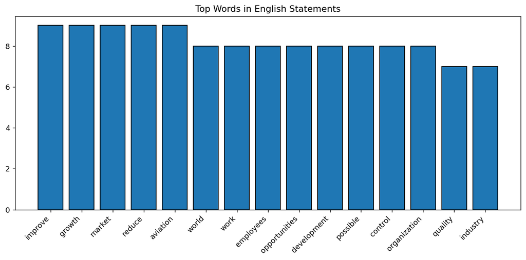

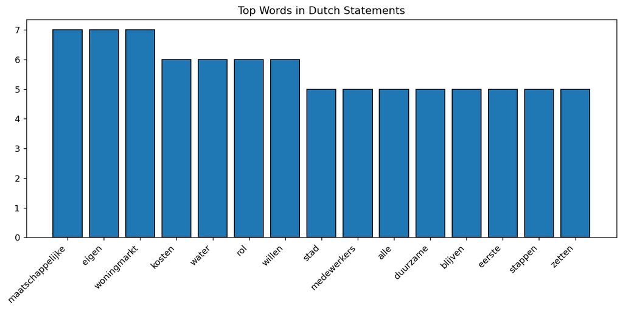

```python
# Plot Frequent words
def plot_word_freq(data_subset, title, token_col="tokens_clean", topn=15):
    # pull flattened token list
    all_tokens = [t for toks in data_subset[token_col].dropna() for t in toks]
    if not all_tokens:
        print(f"No tokens to plot for {title}")
        return
    freq = Counter(all_tokens).most_common(topn)
    words, counts = zip(*freq)

    plt.figure(figsize=(10,5), dpi=130)
    plt.bar(words, counts, edgecolor="black")
    plt.xticks(rotation=45, ha="right")
    plt.title(title)
    plt.tight_layout()
    plt.show()

# Split by language and plot
data_en = data[data["lang"].str.lower() == "en"]
data_nl = data[data["lang"].str.lower() == "nl"]

plot_word_freq(data_en, "Top Words in English Statements")
plot_word_freq(data_nl, "Top Words in Dutch Statements")
```

# Cleaning extra words

```python
# light cleanup
data["lang"] = data["lang"].str.lower().str.strip()
data["Type"] = data["Type"].str.lower().str.strip().replace({
    "core value":"values","core values":"values",
    "mission statement":"mission","vision statement":"vision",
    "goal":"goals"
})
data["Statement"] = data["Statement"].fillna("").astype(str).str.strip()
data["Industry"] = data["Industry"].fillna("").astype(str).str.strip()

# keep the five types only
data = data[data["Type"].isin({"mission","vision","values","goals","strategy"})].copy()
```

```python
# show what unique industries
print("Rows:", len(data))
print("Unique industries:", data["Industry"].nunique())
print(data["Industry"].value_counts().head(15))
```

```
Rows: 325
Unique industries: 10
Industry
Transport            71
Technology           67
Real State           41
Public Sector        40
Utilities            29
Retail               22
Hospitality          19
Finance              18
Consumer Services     9
Healthcare            9
Name: count, dtype: int64
```

# Select subsets (EN, NL x Industry)

This cell splits the dataset by language and industry, keeping only groups with enough rows to make clustering meaningful. It ensures English and Dutch texts are analyzed separately and prints how many subsets were created along with their sizes and unique statement types.

```python
MMIN_ROWS = 15

li_sets = {}
for (lang, ind), dfi in data.groupby(["lang", "Industry"], dropna=False):
    if len(dfi) >= MIN_ROWS:
        li_sets[(lang, ind)] = dfi.copy()

print(f"Created {len(li_sets)} language×industry subsets (≥{MIN_ROWS} rows).")
for k, d in li_sets.items():
    print(f"{k}: rows={len(d)}, unique Types={d['Type'].str.lower().str.strip().nunique()}")
```

[output not shown]

```python
# Gentle vectorizer
tfidf = TfidfVectorizer(min_df=1, ngram_range=(1,1), norm="l2")
k_best, y_pred, km, _ = pick_k_by_silhouette(X, k_min=2, k_max=min(6, X.shape[0]-1))
```

# KMeans Clustering per language per industry

This cell performs automatic clustering for each language and industry subset using K-Means with an optimized number of clusters based on the cosine silhouette score. Instead of fixing the number of clusters, the algorithm tests several values and selects the one that best fits the data. It then calculates cluster purity and silhouette scores to evaluate how consistent and well-separated the clusters are. The printed results show, for each subset, the chosen number of clusters, the achieved purity, and the silhouette score, which together indicate the overall quality of the clustering.

```python
# Purity metric
def cluster_purity(y_true, y_pred):
    """
    Purity = sum of the majority class counts per cluster / total samples.
    Compares predicted clusters against your ground-truth 'Type' labels.
    """
    ct = pd.crosstab(pd.Series(y_true, name="true"),
                     pd.Series(y_pred, name="cluster"))
    return (ct.max(axis=0).sum() / ct.values.sum()) if ct.size else np.nan
```

```python
# Pick k automatically via silhouette (cosine)
def pick_k_by_silhouette(X, k_min=2, k_max=10, random_state=42):
    """
    Try k in [k_min, k_max], pick the one with the best cosine silhouette.
    Skips invalid k for tiny samples. Returns (best_k, best_labels, best_model, scores_dict).
    """
    n = X.shape[0]
    usable_max = max(k_min, min(k_max, n - 1))  # need at least k+1 samples
    scores = {}
    best = {"k": None, "score": -1, "labels": None, "model": None}

    for k in range(k_min, usable_max + 1):
        km = KMeans(n_clusters=k, n_init="auto", random_state=random_state)
        labels = km.fit_predict(X)

        # silhouette needs at least 2 different labels and < n unique labels
        if len(set(labels)) < 2 or len(set(labels)) >= n:
            continue

        try:
            s = silhouette_score(X, labels, metric="cosine")
        except Exception:
            continue

        scores[k] = s
        if s > best["score"]:
            best.update({"k": k, "score": s, "labels": labels, "model": km})

    # Fallback if nothing valid (rare): force k=2
    if best["k"] is None:
        k = min(2, max(2, usable_max))
        km = KMeans(n_clusters=k, n_init="auto", random_state=random_state)
        labels = km.fit_predict(X)
        best = {"k": k, "score": np.nan, "labels": labels, "model": km}
        scores[k] = np.nan

    return best["k"], best["labels"], best["model"], scores
```

```python
# Initialize result containers
tfidfs = {}
Xs     = {}
kms    = {}   # maps (lang, industry) -> (y_true, y_pred, km_model, k_best)
scores = {}   # summary metrics per subset
```

```python
#Vectorize each (lang×industry) subset, auto-select k, evaluate
for (lang, ind), df in li_sets.items():
    # TF-IDF (tune if subset is tiny; this is a good default)
    tfidf = TfidfVectorizer(min_df=2, max_df=0.9, ngram_range=(1,2), norm="l2")
    X = tfidf.fit_transform(df["clean"].fillna(""))

    # Cap k to avoid over-fragmenting small subsets
    k_upper_cap = max(3, min(12, df["Type"].nunique() + 3, X.shape[0] - 1))

    # Auto-pick k using cosine silhouette
    k_best, y_pred, km, k_scores = pick_k_by_silhouette(
        X, k_min=2, k_max=k_upper_cap, random_state=42
    )

    # Evaluate against ground-truth 'Type'
    y_true = df["Type"].astype(str).str.lower().str.strip().values
    pur = round(cluster_purity(y_true, y_pred), 3)
    sil = (round(silhouette_score(X, y_pred, metric="cosine"), 3)
           if X.shape[0] >= (k_best + 2) and len(set(y_pred)) > 1 else np.nan)

    # Store artifacts for later (plots, top-terms, tables)
    tfidfs[(lang, ind)], Xs[(lang, ind)] = tfidf, X
    kms[(lang, ind)] = (y_true, y_pred, km, k_best)
    scores[(lang, ind)] = {
        "rows": len(df),
        "k": k_best,
        "purity": pur,
        "silhouette": sil
    }

    print(f"{lang} | {ind}: k*={k_best} | purity={pur} | silhouette(cosine)={sil}")
```

```
en | Finance: k*=7 | purity=0.556 | silhouette(cosine)=0.43
en | Hospitality: k*=8 | purity=0.684 | silhouette(cosine)=0.4
en | Retail: k*=7 | purity=0.591 | silhouette(cosine)=0.206
en | Technology: k*=8 | purity=0.386 | silhouette(cosine)=0.157
en | Transport: k*=8 | purity=0.462 | silhouette(cosine)=0.059
nl | Public Sector: k*=8 | purity=0.45 | silhouette(cosine)=0.191
nl | Real State: k*=8 | purity=0.463 | silhouette(cosine)=0.25
nl | Utilities: k*=8 | purity=0.621 | silhouette(cosine)=0.383
```

```python
# Summary table silhouette(cosine)
summary_df = (pd.DataFrame([
    {"lang": lang, "industry": ind, **m}
    for (lang, ind), m in scores.items()
]).sort_values(["lang","industry"]).reset_index(drop=True))
summary_df
```

|  | lang | industry | rows | k | purity | silhouette |
| --- | --- | --- | --- | --- | --- | --- |
| 0 | en | Finance | 18 | 7 | 0.556 | 0.430 |
| 1 | en | Hospitality | 19 | 8 | 0.684 | 0.400 |
| 2 | en | Retail | 22 | 7 | 0.591 | 0.206 |
| 3 | en | Technology | 57 | 8 | 0.386 | 0.157 |
| 4 | en | Transport | 65 | 8 | 0.462 | 0.059 |
| 5 | nl | Public Sector | 40 | 8 | 0.450 | 0.191 |
| 6 | nl | Real State | 41 | 8 | 0.463 | 0.250 |
| 7 | nl | Utilities | 29 | 8 | 0.621 | 0.383 |

```python
n = len(df)
tfidf = (TfidfVectorizer(
            stop_words=("english" if lang=="en" else None),
            min_df=1 if n < 25 else 2,
            max_df=0.85,
            ngram_range=(1,2) if n < 25 else (1,2),
            sublinear_tf=True,
            norm="l2",
            max_features=20000)
         )
X = tfidf.fit_transform(df["clean"].fillna(""))
```

```python
k_upper_cap = min(6, X.shape[0]-1)       # <= 6 keeps themes distinct on small sets
k_best, y_pred, km, _ = pick_k_by_silhouette(X, k_min=2, k_max=k_upper_cap)

# When you create KMeans inside pick_k_by_silhouette, use:
# KMeans(n_clusters=k, init="k-means++", n_init=20, random_state=42)
```

```python
# Cluster themes
bad = {"mission","vision","strategy","goals","core value","company","corporation",
       "create","drive","growth","commitment","experience","step ahead","stay step"}

def top_phrases_distinct(texts, labels, topn=8):
    clusters = sorted(set(labels))
    docs = [" ".join([texts[i] for i in range(len(texts)) if labels[i]==c]) for c in clusters]

    def _fit_counts(ngram_range):
        cv = CountVectorizer(ngram_range=ngram_range, min_df=1)  # <- changed to 1
        Xc = cv.fit_transform(docs)
        return cv, Xc

    # try bigrams first; if empty, fall back to (1,2)
    try:
        cv, Xc = _fit_counts((2,2))
        if Xc.shape[1] == 0:
            raise ValueError
    except Exception:
        cv, Xc = _fit_counts((1,2))

    terms = np.array(cv.get_feature_names_out())

    # c-TF-IDF scoring
    tf = Xc.astype(float)
    tf = tf / (tf.sum(axis=1) + 1e-12)
    df_terms = (Xc > 0).sum(axis=0).A1
    idf = np.log((len(clusters)+1) / (df_terms+1)) + 1.0
    scores = tf.multiply(idf)

    def norm(t): return re.sub(r"[^a-z0-9\s\-]+","",t.lower()).strip()

    out = {}
    for i,c in enumerate(clusters):
        row = np.asarray(scores.getrow(i).todense()).ravel()
        idx = row.argsort()[::-1]
        picks, seen = [], []
        for j in idx:
            ph = terms[j]; phn = norm(ph)
            if phn in bad or len(phn) < 3:
                continue
            toks = set(phn.split())
            if any(len(toks & set(s.split()))/len(toks | set(s.split())) > 0.6 for s in seen):
                continue
            seen.append(phn); picks.append(ph)
            if len(picks) == topn: break
        out[c] = picks
    return out
```

```python
for (lang, ind), (y_true, y_pred, km, k) in kms.items():
    df = li_sets[(lang, ind)]
    labels = top_phrases_distinct(df["clean"].tolist(), y_pred, topn=8)
    print("\n" + "="*70)
    print(f"{lang.upper()} — {ind}: Cluster phrases")
    for c in sorted(labels):
        print(f"Cluster {c}: " + "; ".join(labels[c]))
```

```
======================================================================
EN — Finance: Cluster phrases
Cluster 0: achieve company; performance culture; things honest; honest achieve; improving things; company performance; corporate market; corporate financial
Cluster 1: possible build; think banking; banking develop; banking possible; banking relationships; relationships markets; build banking; markets think
Cluster 2: ahead offering; sustainability stay; empower businesses; financial sustainability; communities stay; offering financial; businesses communities; using data
Cluster 3: using data; capabilities better; data capabilities; needs capabilities; better needs; corporate market; corporate financial; company performance
Cluster 4: processes processes; banking clear; clear processes; businesses communities; data capabilities; corporate market; corporate financial; company performance
Cluster 5: date information; information empower; relevant date; capabilities better; data capabilities; corporate market; corporate financial; company performance
Cluster 6: financial corporate; corporate market; provides corporate; businesses communities; data capabilities; company performance; communities stay; clear processes

======================================================================
EN — Hospitality: Cluster phrases
Cluster 0: action opportunity; sustainability climate; climate action; create stakeholders; food quality; food experience; family better; families serve
Cluster 1: single growth; growth growth; growth high; high single; way grow; environment good; food experience; family better
Cluster 2: way grow; food experience; grow create; stakeholders food; experience money; expectations food; money expectations; food safety
Cluster 3: family better; better families; better like; serve commitment; commitment families; families serve; families families; like family
Cluster 4: right thing; opportunities integrity; thing corporation; corporation opportunities; integrity right; open corporation; corporation right; create stakeholders
Cluster 5: good corporation; best good; company market; corporation purpose; purpose company; good commitment; market best; expectations food
Cluster 6: food quality; aim safe; good food; safe environment; quality quality; environment good; create stakeholders; food experience
Cluster 7: providing experience; serve providing; experience core; corporation right; food quality; food experience; family better; families serve

======================================================================
EN — Retail: Cluster phrases
Cluster 0: including technology; growth including; improve offering; offering increase; technology improve; earth unconventional; create honest; create possible
Cluster 1: unconventional coolblue; coolblue wants; action think; things better; stay way; step step; better way; better step
Cluster 2: growth change; flexibility support; open core; coolblue change; drive change; change open; support growth; change change
Cluster 3: coolblue wants; core coolblue; health drive; honest amaze; coolblue friends; main core; like friends; leadership experience
Cluster 4: ways healthier; healthier environment; healthy communities; markets ways; communities markets; markets healthy; leading markets; earth unconventional
Cluster 5: ways healthier; way making; create honest; create possible; culture coolblue; culture like; drive change; drive consumption
Cluster 6: integrity right; platform right; right capabilities; right thing; capabilities growth; thing platform; drive strategy; create honest

======================================================================
EN — Technology: Cluster phrases
Cluster 0: leadership culture; quality leadership; respect employees; results quality; diversity respect; employees quality; culture quality; culture openness
Cluster 1: commitment hybrid; hybrid hybrid; hybrid clear; hybrid systems; vision lead; lead hybrid; clear vision; employees environment
Cluster 2: use amd; active amd; amd industry; performance computing; performance active; high performance; computing employee; industry high
Cluster 3: intelligent edge; build intelligent; platform create; personal computing; create personal; edge platform; intelligent intelligent; industry ensure
Cluster 4: processes processes; environment employees; ensure high; encourage providing; empower organization; employees space; employees social; employees quality
Cluster 5: developing relationships; developing developing; relationships flexibility; respect relationships; world work; edge build; employees space; employees social
Cluster 6: space employees; world work; development opportunities; encourage providing; empower organization; employees social; employees quality; employees environment
```

[output cut: 30 more lines]

```
Cluster 4: waarop waarop; vertrouwen waarop; daeb daeb; daeb waar; dienstverlening dienstverlening; doelstellingen amsterdam; duurzaam activiteiten; dynamiek amsterdam
Cluster 5: doelstellingen amsterdam; amsterdam woningen; woningen woningen; zetten woningmarkt; eigen vermogen; daeb waar; dienstverlening dienstverlening; duurzaam activiteiten
Cluster 6: streven aantal; aantal aantal; eigenaarschap willen; dienstverlening dienstverlening; doelstellingen amsterdam; duurzaam activiteiten; dynamiek amsterdam; dynamiek stad
Cluster 7: dienstverlening dienstverlening; alle dienstverlening; zetten woningmarkt; eigenaarschap woningmarkt; doelstellingen amsterdam; duurzaam activiteiten; dynamiek amsterdam; dynamiek stad

======================================================================
NL — Utilities: Cluster phrases
Cluster 0: brabant water; stellen brabant; water levert; veilig stellen; water alle; alle processen; water stakeholders; water veilig
Cluster 1: bijdrage wereld; vertrouwen maatschappelijk; kosten laag; maatschappelijk digitalisering; wereld waar; mogelijke kosten; omgeving voldoende; digitalisering alle
Cluster 2: eigen eigen; eigen duurzame; wereld water; brabant water; levert water; laag mogelijke; kosten vertrouwen; kosten laag
Cluster 3: stellen stellen; wereld water; laag mogelijke; kosten vertrouwen; kosten laag; eigen eigen; eigen duurzame; duurzame duurzame
Cluster 4: duurzame duurzame; duurzaam duurzame; wereld water; brabant water; levert water; laag mogelijke; kosten vertrouwen; kosten laag
Cluster 5: aantrekkelijk blijven; active rol; digitalisering alle; levert water; laag mogelijke; kosten vertrouwen; kosten laag; eigen eigen
Cluster 6: oog maatschappelijke; rol water; stakeholders active; maatschappelijke stakeholders; bijdrage anderen; maatschappelijke rol; belangrijke maatschappelijke; belangrijke bijdrage
Cluster 7: wereld water; water medewerkers; medewerkers belangrijke; belangrijke wereld; brabant water; laag mogelijke; kosten vertrouwen; kosten laag
```

# Mission–Goals Semantic Alignment by Industry

We will create a prototype that measures how closely each company’s mission and goals statements align in meaning. Using TF-IDF, we’ll convert both texts into numerical vectors and calculate the cosine similarity between them. This produces a coherence score for each company, showing how semantically consistent their mission and goals are.

```python
# Build simple per-company mission/goals strings
mg = (data
      .pivot_table(index=["Company","Industry","lang"],
                   columns="Type",
                   values="clean",
                   aggfunc=lambda x: " ".join(x))
      .reset_index())

# keep rows where both exist
mg = mg[mg["mission"].notna() & mg["goals"].notna()].copy()

# Vectorize both columns jointly to a common space
vec = TfidfVectorizer(min_df=1, ngram_range=(1,2), norm="l2")
M = vec.fit_transform(mg["mission"].fillna(""))
G = vec.transform(mg["goals"].fillna(""))

# Cosine similarity
from sklearn.metrics.pairwise import cosine_similarity
mg["MissionGoalsCosine"] = np.diag(cosine_similarity(M, G))

# Company-level report (optional)
mg[["Company","Industry","lang","MissionGoalsCosine"]].sort_values(
    "MissionGoalsCosine", ascending=False).head(10)
```

| Type | Company | Industry | lang | MissionGoalsCosine |
| --- | --- | --- | --- | --- |
| 18 | de key | Real State | nl | 0.692573 |
| 4 | Lufthansa | Transport | en | 0.507093 |
| 9 | Philips | Healthcare | en | 0.491404 |
| 14 | basic fit | Consumer Services | en | 0.436495 |
| 19 | ibm | Technology | en | 0.421212 |
| 16 | brabant water | Utilities | nl | 0.396575 |
| 8 | Ordina | Technology | nl | 0.310179 |
| 11 | advanced micro device | Technology | en | 0.284824 |
| 2 | Kadaster | Public Sector | nl | 0.272348 |
| 15 | belastingdienst | Public Sector | nl | 0.258242 |

```python
# Make an industry-level series for plotting
coherence_df = mg[["Company","Industry","lang","MissionGoalsCosine"]].copy()

coh_by_ind = (coherence_df
              .groupby("Industry")["MissionGoalsCosine"]
              .mean()
              .sort_values(ascending=True))
```

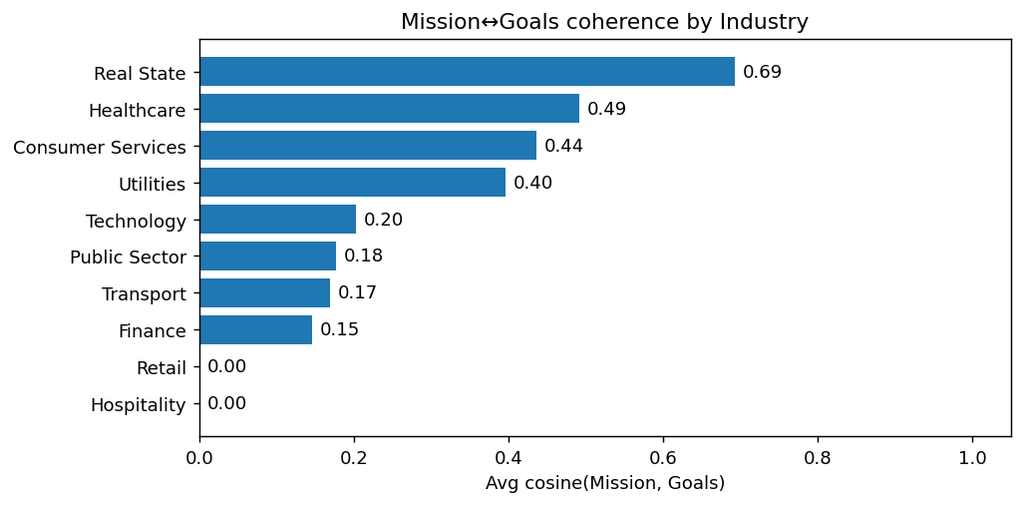

```python
coh_plot = coh_by_ind.sort_values(ascending=True)
plt.figure(figsize=(8, max(3, 0.4*len(coh_plot))), dpi=130)
plt.barh(coh_plot.index, coh_plot.values)
plt.xlabel("Avg cosine(Mission, Goals)")
plt.title("Mission↔Goals coherence by Industry")
for y, v in enumerate(coh_plot.values):
    plt.text(v + 0.01, y, f"{v:.2f}", va="center")
plt.xlim(0, 1.05)
plt.tight_layout()
plt.show()
```